# vyshnavi task1

IMPORT THE LIBRARIES

```python
import pandas as pd
import numpy as np
import matplotlib.pyplot as plt
import seaborn as sns
print("Libraries imported successfully")
```

```
Libraries imported successfully
```

NOW LOAD THE SALES DATASET

```python
df = pd.read_csv('Sales Dataset.csv')
print('Dataset loaded successfully')
```

```
Dataset loaded successfully
```

INITIAL DATA INSPECTION

```python
df.head()
```

|  | im | Date | Gender | Age | Product Category | Quantity | Price per Unit | Total Amount |
| --- | --- | --- | --- | --- | --- | --- | --- | --- |
| 0 | 0 | 2023-11-24 | Male | 34 | Beauty | 3 | 50 | 150 |
| 1 | 1 | 2023-02-27 | Female | 26 | Clothing | 2 | 500 | 1000 |
| 2 | 2 | 2023-01-13 | Male | 50 | Electronics | 1 | 30 | 30 |
| 3 | 3 | 2023-05-21 | Male | 37 | Clothing | 1 | 500 | 500 |
| 4 | 4 | 2023-05-06 | Male | 30 | Beauty | 2 | 50 | 100 |

```python
print("Number of rows and columns:")
print(df.shape)
```

```
Number of rows and columns:
(1000, 8)
```

```python
print("Data types")
print(df.dtypes)
```

```
Data types
im                  int64
Date                  str
Gender                str
Age                 int64
Product Category      str
Quantity            int64
Price per Unit      int64
Total Amount        int64
dtype: object
```

```python
print("missing values:")
print(df.isnull().sum())
```

```
missing values:
im                  0
Date                0
Gender              0
Age                 0
Product Category    0
Quantity            0
Price per Unit      0
Total Amount        0
dtype: int64
```

DESCRIPTIVE STATISTICS

```python
df.describe()
```

|  | im | Age | Quantity | Price per Unit | Total Amount |
| --- | --- | --- | --- | --- | --- |
| count | 1000.000000 | 1000.00000 | 1000.000000 | 1000.000000 | 1000.000000 |
| mean | 499.500000 | 41.39200 | 2.514000 | 179.890000 | 456.000000 |
| std | 288.819436 | 13.68143 | 1.132734 | 189.681356 | 559.997632 |
| min | 0.000000 | 18.00000 | 1.000000 | 25.000000 | 25.000000 |
| 25% | 249.750000 | 29.00000 | 1.000000 | 30.000000 | 60.000000 |
| 50% | 499.500000 | 42.00000 | 3.000000 | 50.000000 | 135.000000 |
| 75% | 749.250000 | 53.00000 | 4.000000 | 300.000000 | 900.000000 |
| max | 999.000000 | 64.00000 | 4.000000 | 500.000000 | 2000.000000 |

AFTER GOING TO TIME SERIES ANALYSIS

MONTHLY SALES DATASET TREND

firstly,convert the data column to datetime,calculate monthly sales,convert the period to timestamp for plotting,now plot monthly sales dataset trend.

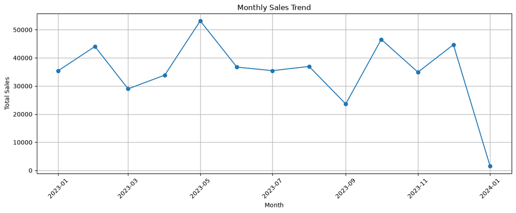

```python
df['Date'] = pd.to_datetime(df['Date'])
monthly_sales = df.groupby(df['Date'].dt.to_period('M'))['Total Amount'].sum()
monthly_sales.index=monthly_sales.index.to_timestamp()
plt.figure(figsize=(12,5))
plt.plot(monthly_sales.index,monthly_sales.values,marker='o')
plt.title('Monthly Sales Trend')
plt.xlabel('Month')
plt.ylabel('Total Sales')
plt.xticks(rotation=45)
plt.grid(True)
plt.tight_layout()
plt.show()
```

observation:Here,from the above chart we can observe that the peaks show the highest sale and the decline show the lowest sale

QUATERLY SALES TREND

firstly calculate quaterly sales and convert period to timetamp,plot quaterly sales trend.

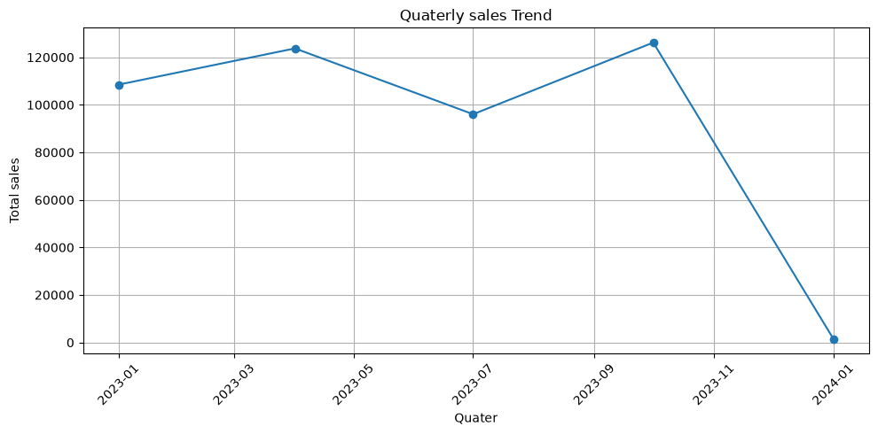

```python
quaterly_sales = df.groupby(df['Date'].dt.to_period('Q'))['Total Amount'].sum()
quaterly_sales.index = quaterly_sales.index.to_timestamp()
plt.figure(figsize=(10,5))
plt.plot(quaterly_sales.index,quaterly_sales.values,marker='o')
plt.title('Quaterly sales Trend')
plt.xlabel('Quater')
plt.ylabel('Total sales')
plt.xticks(rotation=45)
plt.grid(True)
plt.tight_layout()
plt.show()
```

CUSTOMER DEMOGRAPHIC ANLAYSIS

CUSTOMER AGE GROUPS

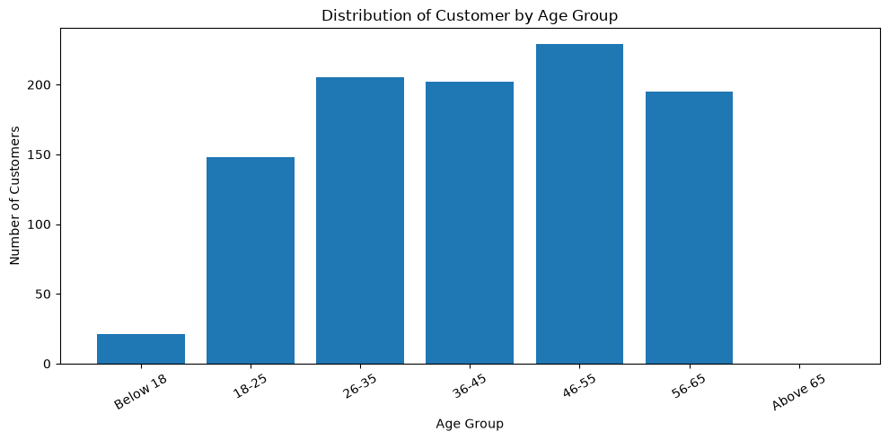

```python
bins = [0,18,25,35,45,55,65,100]
labels = ['Below 18', '18-25' , '26-35' , '36-45' , '46-55' , '56-65' , 'Above 65']
df['Age Group'] = pd.cut(df['Age'],bins=bins,labels=labels,include_lowest=True)
age_group_counts = df['Age Group'].value_counts().sort_index()
plt.figure(figsize=(10,5))
plt.bar(age_group_counts.index.astype(str),age_group_counts.values)
plt.title('Distribution of Customer by Age Group')
plt.xlabel('Age Group')
plt.ylabel('Number of Customers')
plt.xticks(rotation=30)
plt.tight_layout()
plt.show()
```

observation:From the above graph the 46-55 age group has the highest number of customers,while customers below 18 and above 65 are very low.overall,most customers are between 26 and 65 years.

GENDER BREAKDOWN

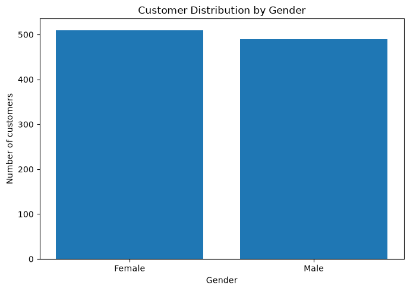

```python
gender_counts = df['Gender'].value_counts()
plt.figure(figsize=(7,5))
plt.bar(gender_counts.index,gender_counts.values)
plt.title('Customer Distribution by Gender')
plt.xlabel('Gender')
plt.ylabel('Number of customers')
plt.tight_layout()
plt.show()
```

observation:From the above graph the number of female customers is slightly higher than male customers,showing a nearly balanced gender distribution.

PRODUCT ANALYSIS

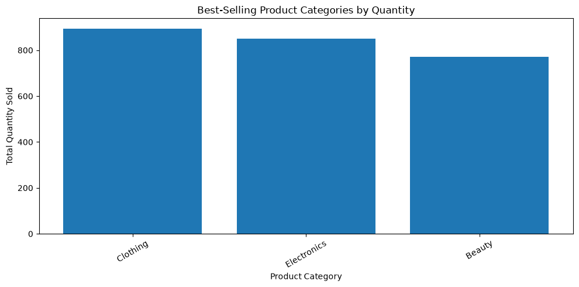

```python
category_quantity = (df.groupby('Product Category')['Quantity'].sum().sort_values(ascending=False).head(10))
plt.figure(figsize=(10,5))
plt.bar(category_quantity.index,category_quantity.values)
plt.title('Best-Selling Product Categories by Quantity')
plt.xlabel('Product Category')
plt.ylabel('Total Quantity Sold')
plt.xticks(rotation=30)
plt.tight_layout()
plt.show()
```

observation:From the above graph clothing is the best-selling catrgory,followed by electronics,while beauty has the lowest quantity sold.

REVENUE BY PRODUCT CATEGORY

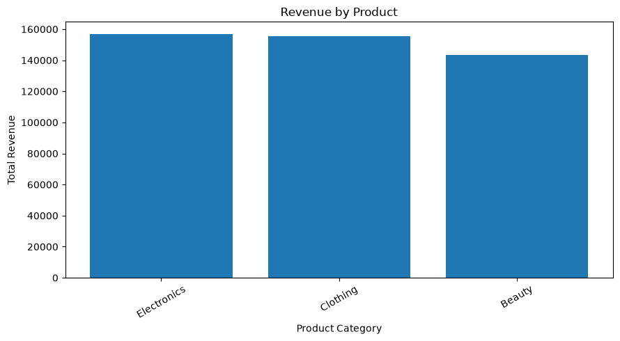

```python
category_revenue = (df.groupby('Product Category')['Total Amount'].sum().sort_values(ascending=False))
plt.figure(figsize=(9,5))
plt.bar(category_revenue.index,category_revenue.values)
plt.title('Revenue by Product')
plt.xlabel('Product Category')
plt.ylabel('Total Revenue')
plt.xticks(rotation=30)
plt.tight_layout()
plt.show()
```

observation:From the above graph,Electronics and clothing generate the highest revenue,while beauty has the lowest revenue among the three categories.

CORRELATION HEATMAP

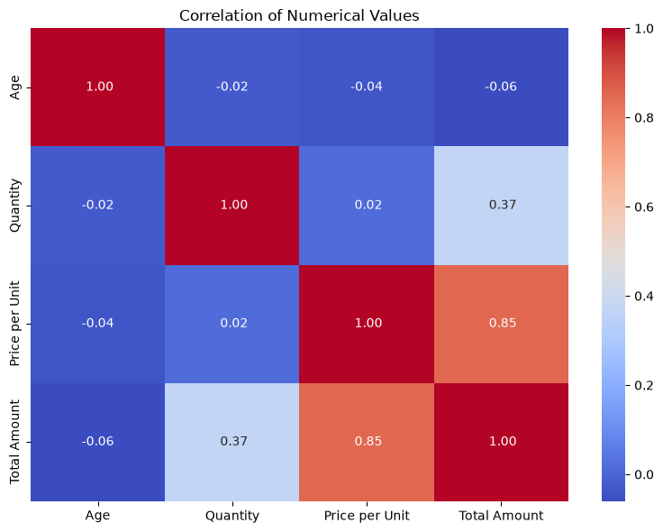

```python
numerical_columns = ['Age' , 'Quantity' , 'Price per Unit' , 'Total Amount']
correlation_matrix = df[numerical_columns].corr()
plt.figure(figsize=(8,6))
sns.heatmap(correlation_matrix,annot=True,cmap='coolwarm',fmt=' .2f')
plt.title('Correlation of Numerical Values')
plt.tight_layout()
plt.show()
```

observation:The correlation heatmap is a strong relationship between price per unit and Total Amount(0.85).quantity also has a moderate relationship with total amount(0.37),while age has very little correlation with the other variables

ADDITIONAL VISUALIZATION

spending by Age Group

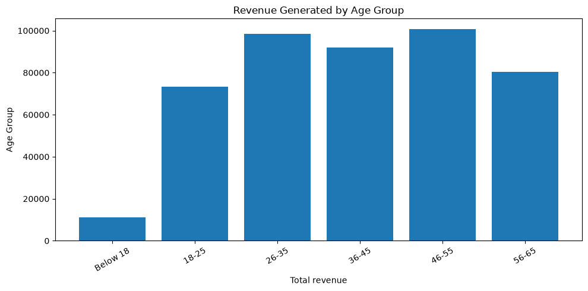

```python
age_revenue = (df.groupby('Age Group',observed=True)['Total Amount'].sum())
plt.figure(figsize=(10,5))
plt.bar(age_revenue.index.astype(str),age_revenue.values)
plt.title('Revenue Generated by Age Group')
plt.ylabel('Age Group')
plt.xlabel('Total revenue')
plt.xticks(rotation=30)
plt.tight_layout()
plt.show()
```

observation:From the above graph the age 45-55 age group contibute the highest revenue,followed by26-35 and 36-45.The below 18 group contributes the least revenue,indicating the middle-aged customers are the major revenue contributors.

Actionable Recommendations:1.Focus marketing efforts,as they generate the highest revenue. 2.offer personalised discounts and loyolty programs to high -value customers. 3.improve promotions 4.use targeted age-specific products and offers based on customer preferences

conclusion:The exploratory Data Analysis of the Sales Dataset,provide valuable insights into monthly,quaterly sales performance,customer demographic analysis,product,correlation matrix between numerical variables.